# Example of placement analysis using BoSSA

Please report comments or bugs to Pierre Lefeuvre - pierre.lefeuvre@cirad.fr

[BoSSA CRAN page](https://cran.r-project.org/package=BoSSA)

# Summary

A phylogenetic placement corresponds to the position of a query sequence in a reference tree. Different tools exits to infer phylogenetic placements, such as [pplacer](https://matsen.fhcrc.org/pplacer/), [EPA](http://sco.h-its.org/exelixis/web/software/epa/index.html) or RAPPAS. Importantly, these three programs produce placements under a common [file format](https://journals.plos.org/plosone/article?id=10.1371/journal.pone.0031009). Placements can later be analysed using the [guppy](https://matsen.github.io/pplacer/generated_rst/guppy.html) software from the pplacer suite to obtain statistically based taxonomic classification of sequences. The BoSSA package implements functions to reads, plots and summarizes phylogentic placements. This vignette is intended to provide examples of placements analyses using BoSSA.

# Important note

- The placement mass (potentially) available in the jplace and sqlite files are imported in R (within the jplace and pplace objects) but aren’t use in the analysis. You should use the “N” parameter (available in several fucntions for the package) to use different weight for each placement.
- The reference packages shiped with BoSSA are incomplete (they lack the alignment file) in order to reduce the package size. Whereas, the information available is sufficient to draw summary statistics, it won’t be enough to perform actual phylogenetic placement.
- When the jplace or sqlite files are import into R, the node numbering available in the original file is converted to the class “phylo” numbering.

# How to obtain phylogentic placement file suitable for analysis with BoSSA ?

The process to obtain placement files is dependent of the program you use. Assuming you are using pplacer, the process would be (1) build a reference package that contains an align set of reference sequences and a reference phylogenetic tree, (2) align query sequences to the reference alignment, (3) use pplacer to infer placements (jplace file output, format describe [here](https://journals.plos.org/plosone/article?id=10.1371/journal.pone.0031009)) and optionally (4) infer the classification of each sequences using guppy (sqlite file output).

- The construction of the reference package could be a bit tricky. The taxtastic tool is extremely helpfull to this end. A tutorial can be find [here](http://fhcrc.github.io/taxtastic/quickstart.html). A BoSSA vignette on refpkg construction is also available.
- [HMMER](http://hmmer.org/) and [MAFFT](https://mafft.cbrc.jp/alignment/software/addsequences.html) can be use to align sequences to a reference alignment.
- For phylogenetic placement, a detailed tutorial is available [here](http://fhcrc.github.io/microbiome-demo/).

Let’s say you have obtained a reference package (refpkg), a placement file (jplace file) and a guppy classification output (sqlite file). The example files presented here are derived from other [reference packages and jplaces files](https://github.com/fhcrc/microbiome-demo/zipball/master) from the [Matsen group pplacer tutorials](https://fhcrc.github.io/microbiome-demo/). The sqlite file was obtained using the following command:

```
guppy classify --multiclass-min 0 --cutoff 0.5 -c example.refpkg --sqlite example.sqlite example.jplace
```

# Exploration of a reference package

Let’s start by loading the `BoSSA-package:

```r
library("BoSSA")
```

A good practice would be to inspect the refpkg content.

```r
refpkg_path <- paste(find.package("BoSSA"),"/extdata/example.refpkg",sep="")
refpkg(refpkg_path)
```

```
## ### Reference package summary
##
## Path:/tmp/RtmpK6GO3B/Rinst3a903489a3e2/BoSSA/extdata/example.refpkg
##
## Tree with 652 tips 650 nodes
##
## Classification:
## root 1
## below_root 1
## superkingdom 1
## below_superkingdom 1
## below_below_superkingdom 1
## superphylum 1
## phylum 6
## subphylum 1
## class 11
## subclass 2
## order 15
## below_order 3
## below_below_order 1
## suborder 3
## family 28
## below_family 5
## genus 45
## species_group 6
## species_subgroup 1
## species 138
```

It is possible to extract the taxonomy of the sequences included in the refpkg.

```r
taxo <- refpkg(refpkg_path,type="taxonomy")
head(taxo)
```

```
##   tax_id parent_id                     rank                     tax_name root
## 1      1         1                     root                         root    1
## 2 131567         1               below_root           cellular organisms    1
## 3      2    131567             superkingdom                     Bacteria    1
## 4   2323         2       below_superkingdom        unclassified Bacteria    1
## 5  95818      2323 below_below_superkingdom       candidate division TM7    1
## 6  68336         2              superphylum Bacteroidetes/Chlorobi group    1
##   below_root superkingdom below_superkingdom below_below_superkingdom
## 1
## 2     131567
## 3     131567            2
## 4     131567            2               2323
## 5     131567            2               2323                    95818
## 6     131567            2
##   superphylum phylum subphylum class subclass order below_order
## 1
## 2
## 3
## 4
## 5
## 6       68336
##   below_below_order suborder family below_family genus species_group
## 1
## 2
## 3
## 4
## 5
## 6
##   species_subgroup species below_species
## 1
## 2
## 3
## 4
## 5
## 6
```

or display a pie chart that summarize the taxonomy…

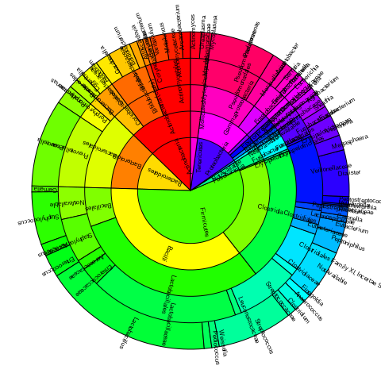

```r
refpkg(refpkg_path,type="pie",cex.text=0.5)
```

… or a subset of the taxonomy levels. Here, an example with the “class”, “order” and “family” levels. Note there is a slight decay between the text labels and slices… this will need a fix in a future package update.

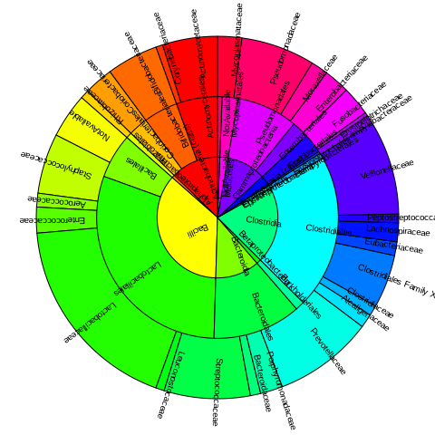

```r
refpkg(refpkg_path,type="pie",rank_pie=c("class","order","family"),cex.text=0.6)
```

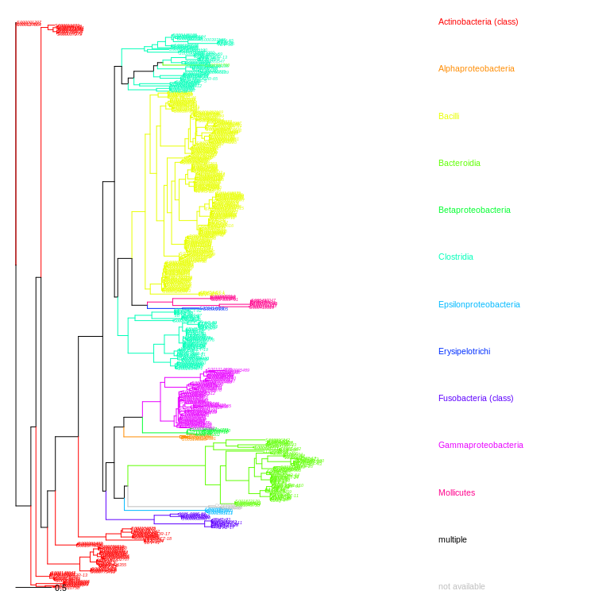

```r
refpkg(refpkg_path,type="tree",rank_tree="class",cex.text=0.5)
```

# Loading the example data

The BoSSA package comes along with examples of phylogenetic placements from the Masten group.

```r
sqlite_file <- system.file("extdata", "example.sqlite", package = "BoSSA")
jplace_file <- system.file("extdata", "example.jplace", package = "BoSSA")
```

To read the data, use the `read_sqlite` function.

```r
pplace <- read_sqlite(sqlite_file,jplace_file)
pplace
```

```
## pplace object
## run: 1
## call run 1: /home/lefeuvre/prgrm_phylo/pplacer/pplacer-Linux-v1.1.alpha18-2-gcb55169/guppy classify --multiclass-min 0 --cutoff 0.5 -c example.refpkg --sqlite example.sqlite example.jplace
## Placement on a phylogenetic tree with 652 tips and 650 internal nodes.
## sequence nb: 100
## placement nb: 30
```

A summary of the object is printed with the number of runs, the command line, a short description of the phylogenetic tree, the number of placements and the number of sequences being placed. Pplace objects are stored in a list of 15 components, with 12 components being outputs from a [guppy classify](https://matsen.github.io/pplacer/generated_rst/guppy_classify.html#guppy-classify) run and 3 components corresponding to the phylogenetic tree used for placement:

```r
str(pplace)
```

```
## List of 15
##  $ multiclass                 :'data.frame': 100 obs. of  6 variables:
##   ..$ placement_id: int [1:100] 28 22 1 28 5 3 9 28 17 28 ...
##   ..$ name        : chr [1:100] "GLKT0ZE01A0Y5X" "GLKT0ZE01A1B65" "GLKT0ZE01A608I" "GLKT0ZE01A6F1M" ...
##   ..$ want_rank   : chr [1:100] "species" "species" "species" "species" ...
##   ..$ rank        : chr [1:100] "species" "genus" "species" "species" ...
##   ..$ tax_id      : chr [1:100] "40543" "168808" "906_1" "40543" ...
##   ..$ likelihood  : num [1:100] 1 1 1 1 1 ...
##  $ placement_classifications  :'data.frame': 280 obs. of  3 variables:
##   ..$ placement_id: int [1:280] 1 1 1 1 1 1 1 1 1 2 ...
##   ..$ tax_id      : chr [1:280] "1" "131567" "2" "1239" ...
##   ..$ likelihood  : num [1:280] 1 1 1 1 1 ...
##  $ placement_evidence         :'data.frame': 630 obs. of  4 variables:
##   ..$ placement_id: int [1:630] 1 1 1 1 1 1 1 1 1 1 ...
##   ..$ rank        : chr [1:630] "root" "below_root" "superkingdom" "below_superkingdom" ...
##   ..$ evidence    : num [1:630] 0 0 0 0 0 0 0 0 0 0 ...
##   ..$ bayes_factor: num [1:630] NA NA NA NA NA NA NA NA NA NA ...
##  $ placement_median_identities:'data.frame': 0 obs. of  3 variables:
##   ..$ placement_id           : int(0)
##   ..$ tax_id                 : chr(0)
##   ..$ median_percent_identity: num(0)
##  $ placement_names            :'data.frame': 100 obs. of  4 variables:
##   ..$ placement_id: int [1:100] 1 2 2 3 3 3 4 4 4 5 ...
##   ..$ name        : chr [1:100] "GLKT0ZE01A608I" "GLKT0ZE01DNHR0" "GLKT0ZE01EDYPL" "GLKT0ZE01AHXIQ" ...
##   ..$ origin      : chr [1:100] "example" "example" "example" "example" ...
##   ..$ mass        : num [1:100] 1 1 1 1 1 1 1 1 1 1 ...
##  $ placement_nbc              :'data.frame': 0 obs. of  3 variables:
##   ..$ placement_id: int(0)
##   ..$ tax_id      : chr(0)
##   ..$ bootstrap   : num(0)
##  $ placement_positions        :'data.frame': 193 obs. of  9 variables:
##   ..$ placement_id      : int [1:193] 1 1 1 1 1 1 1 2 2 2 ...
##   ..$ location          : num [1:193] 555 556 553 552 557 554 550 111 115 113 ...
##   ..$ ml_ratio          : num [1:193] 0.143 0.143 0.143 0.143 0.143 ...
##   ..$ log_like          : num [1:193] -11608 -11608 -11608 -11608 -11608 ...
##   ..$ distal_bl         : num [1:193] 5.15e-07 5.15e-07 5.15e-07 7.80e-06 5.78e-06 ...
##   ..$ pendant_bl        : num [1:193] 0.0584 0.0584 0.0584 0.0584 0.0584 ...
##   ..$ tax_id            : chr [1:193] "906_1" "906_1" "906_1" "906_1" ...
##   ..$ map_identity_ratio: num [1:193] NA NA NA NA NA NA NA NA NA NA ...
##   ..$ map_identity_denom: int [1:193] NA NA NA NA NA NA NA NA NA NA ...
```

[output cut: 13 more lines]

```
##  $ taxa                       :'data.frame': 281 obs. of  3 variables:
##   ..$ tax_id  : chr [1:281] "1" "103621" "109790" "113286" ...
##   ..$ tax_name: chr [1:281] "root" "Actinomyces urogenitalis" "Lactobacillus jensenii" "Pseudoramibacter" ...
##   ..$ rank    : chr [1:281] "root" "species" "species" "genus" ...
##  $ arbre                      :List of 5
##   ..$ edge       : int [1:1301, 1:2] 653 654 655 656 657 658 658 657 656 659 ...
##   ..$ edge.length: num [1:1301] 0.0014 0.2102 0.0728 0.1295 0.1131 ...
##   ..$ Nnode      : int 650
##   ..$ tip.label  : chr [1:652] "S000010758" "S002034883" "S000006177" "S001188095" ...
##   ..$ root.edge  : num 0
##   ..- attr(*, "class")= chr "phylo"
##   ..- attr(*, "order")= chr "cladewise"
##  $ edge_key                   : num [1:2, 1:1301] 1 1298 2 1296 3 ...
##  $ original_tree              : chr "((((((S000010758:0.0192957{0},S002034883:0.0325555{1}):0.113088{2},S000006177:0.204859{3}):0.129507{4},(S001188"| __truncated__
##  - attr(*, "class")= chr "pplace"
```

Among these:

- the `run` element contains the run id and the command line summary
- the `taxa` element is a data frame with the whole taxonomy available in the reference package
- the `multiclass` element is a data frame with the taxonomic assignation of each placement
- the `placement_positions` element is a data frame with the position of each placement over the reference phylogenetic tree
- the `arbre` element is the class `phylo` object of the reference phylogenetic tree

# Some plots

Four different plots are available to display placements on a phylogenetic tree:

- the `number` plot. Placement number associated to each branch is indicated. Note that this representation may be hard to read due to overlaps between number boxes. Placement numbers are obtained after the multiplication of their weights with the ML ratio of the placement probabilities. Placement sizes are later round. A zero indicates a size superior to 0 but inferior to 1.

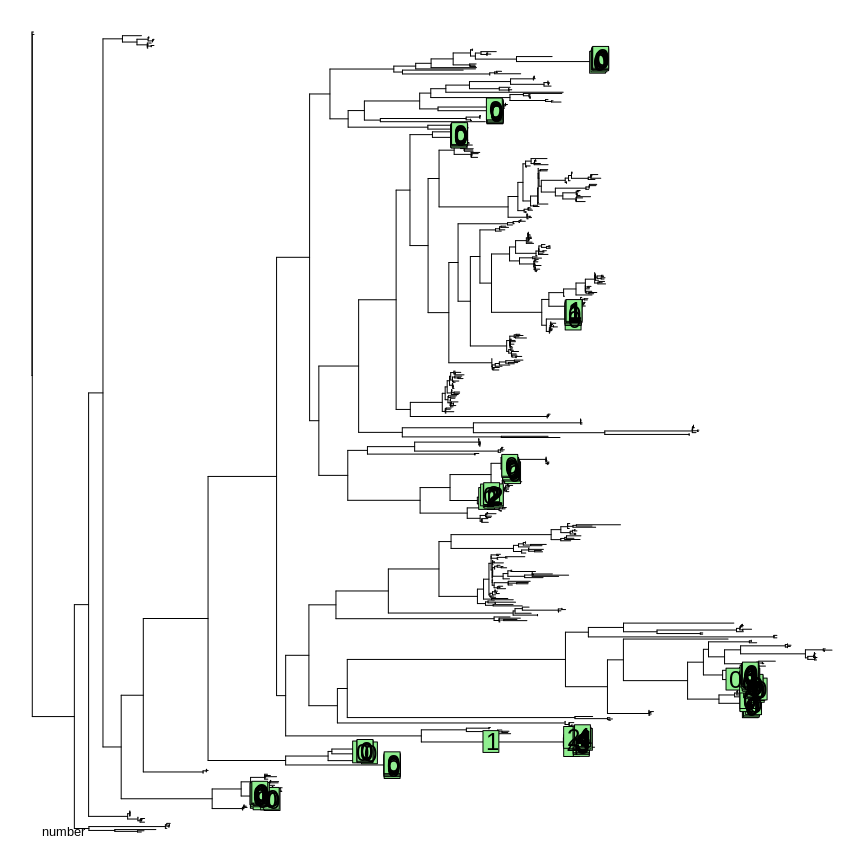

```r
plot(pplace,type="number",main="number",cex.number=1.5)
```

- the `color` plot is the best option. Branches with placement are colored according to the number of sequences they bear.

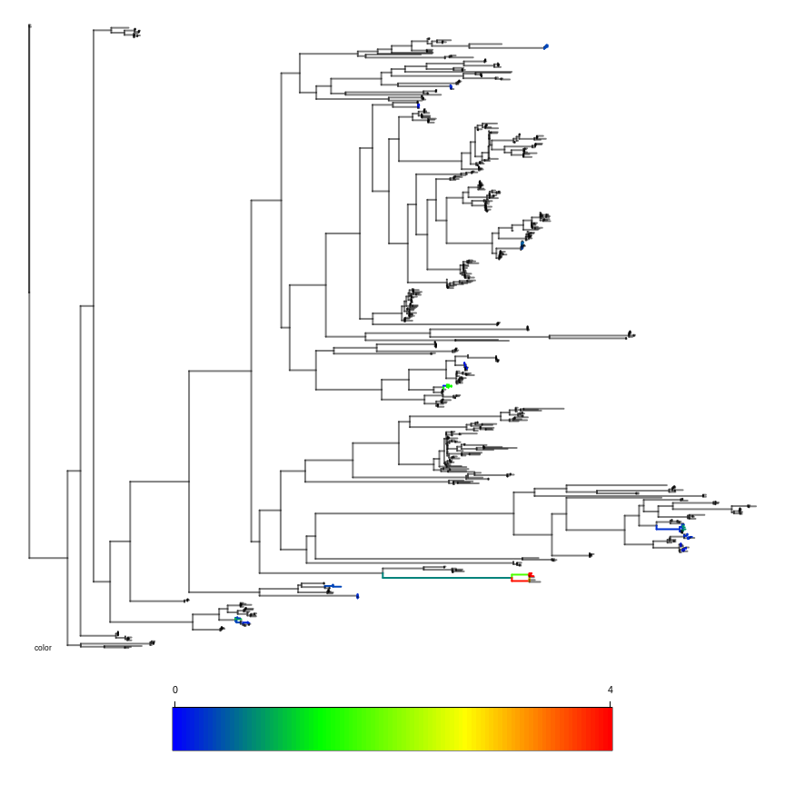

```r
plot(pplace,type="color",main="color",edge.width=2)
```

- in the `fattree` plot, branch wicth is proportionnal to the number of sequences they bear.

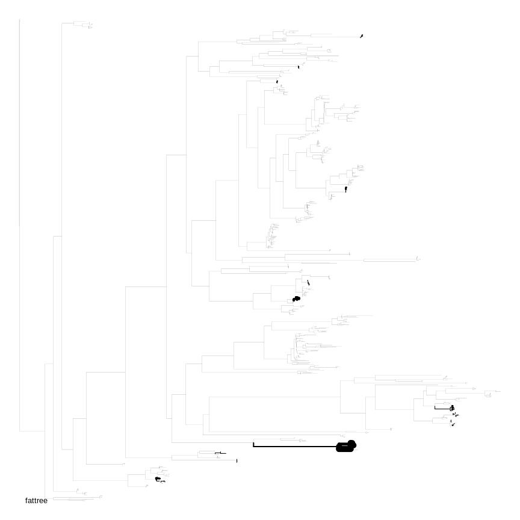

```r
plot(pplace,type="fattree",main="fattree")
```

- in the `precise` plot dots are drawn at the exact placement positions. Whereas the color of the dots depend of the pendant branch length, their sizes depend on the placement sizes. Note that placements are drawn one above the other.

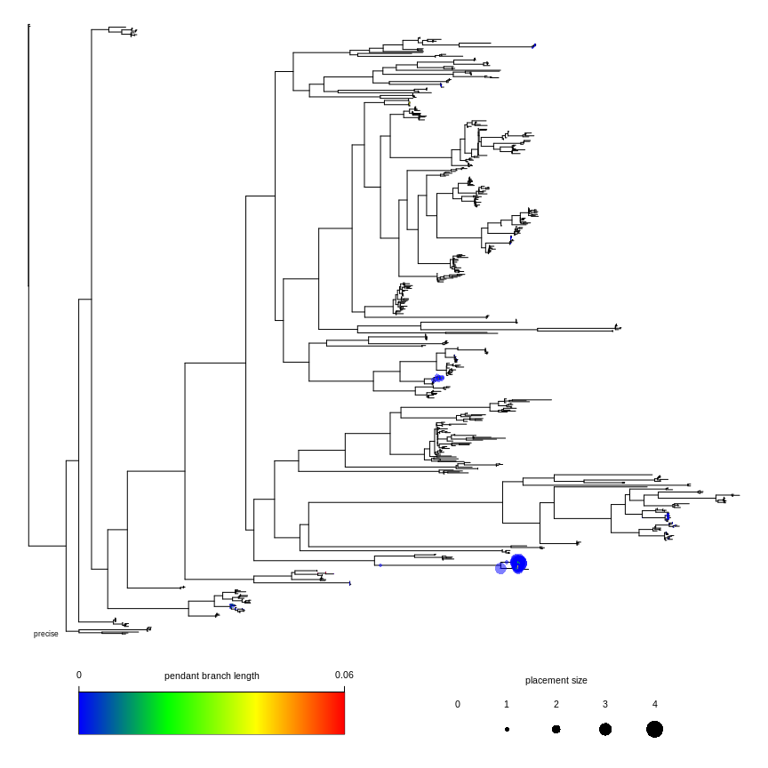

```r
plot(pplace,type="precise",main="precise")
```

Note that it is possible to apply a function to modify the dot size using the `transfo` option. In the following example, the dot size is multiplied by 2. In some other cases `log` or `log10` transformations could be usefull. Beware that when using the `transfo` option, the legend does not anymore correspond to the placement size but to the transform dot size (*i.e.* the transform function applied to the dot size).

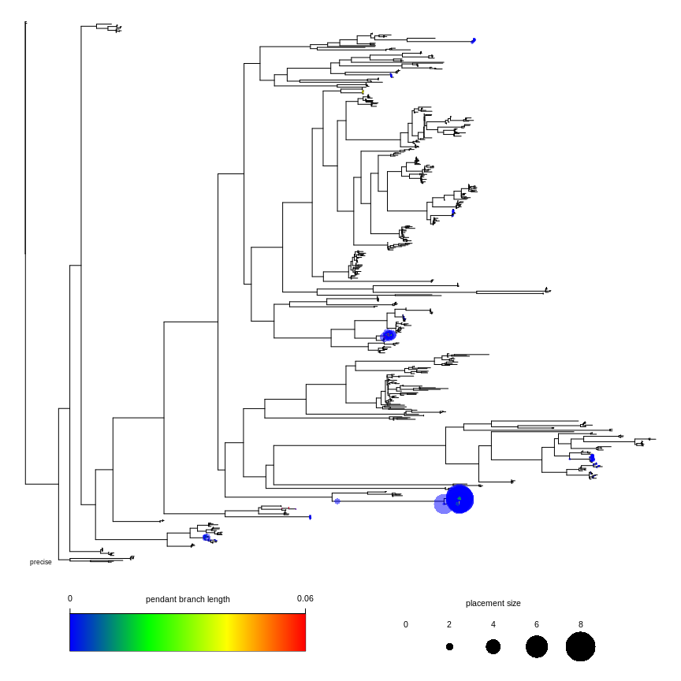

```r
plot(pplace,type="precise",main="precise",transfo=function(X){X*2})
```

# Subsetting the pplace object

Placement object can be subseted. This could be done using placements ids…

```r
sub1 <- sub_pplace(pplace,placement_id=1:100)
sub1
```

```
## pplace object
## run: 1
## call run 1: /home/lefeuvre/prgrm_phylo/pplacer/pplacer-Linux-v1.1.alpha18-2-gcb55169/guppy classify --multiclass-min 0 --cutoff 0.5 -c example.refpkg --sqlite example.sqlite example.jplace
## Placement on a phylogenetic tree with 652 tips and 650 internal nodes.
## sequence nb: 100
## placement nb: 30
```

…or using placements names.

```r
ids <- sample(pplace$multiclass$name,50)
sub2 <- sub_pplace(pplace,ech_id=ids)
sub2
```

```
## pplace object
## run: 1
## call run 1: /home/lefeuvre/prgrm_phylo/pplacer/pplacer-Linux-v1.1.alpha18-2-gcb55169/guppy classify --multiclass-min 0 --cutoff 0.5 -c example.refpkg --sqlite example.sqlite example.jplace
## Placement on a phylogenetic tree with 652 tips and 650 internal nodes.
## sequence nb: 50
## placement nb: 19
```

# Conversion

### To a table

Using the `pplace_to_table` function produces a table that contains the placement information along with the classification for each sequence. The output can be limited to the “best” placement (as in the example, i.e. the placements with the highest likelihood for each sequence).

```r
pplace_table <- pplace_to_table(pplace,type="best")
head(pplace_table,n=3)
```

```
##   placement_id           name want_rank    rank tax_id_multilcass likelihood
## 1            1 GLKT0ZE01A608I   species species             906_1          1
## 2            2 GLKT0ZE01EDYPL   species   genus             84111          1
## 3            3 GLKT0ZE01AHXIQ   species species              2702          1
##   location  ml_ratio  log_like    distal_bl   pendant_bl tax_id_placement
## 1      555 0.1428572 -11607.93 5.149085e-07 5.842901e-02            906_1
## 2      111 0.1428571 -11011.07 5.149085e-07 6.113515e-06            84111
## 3       69 0.1428591 -11606.63 5.149085e-07 6.113515e-06             2702
##   map_identity_ratio map_identity_denom
## 1                 NA                 NA
## 2                 NA                 NA
## 3                 NA                 NA
```

### To a contingency matrix

The `pplace_to_matrix` produces a contingency table. Let say the first 50 sequences in the multiclass table correspond to sequence from “sample 1” and the following 50 correspond to “sample 2”, the function output a contingency table for these two samples. You can either have the taxonomic names (tax_name=TRUE, in the example) or keep the taxonomic ids (tax_name=FALSE).

```r
example_contingency <- pplace_to_matrix(pplace,c(rep("sample1",50),rep("sample2",50)),tax_name=TRUE)
example_contingency
```

```
##         Sneathia sanguinegens Sneathia Megasphaera sp. type 1 Atopobium vaginae
## sample1                    17       12                      6                 1
## sample2                    14       14                      5                 1
##         Gardnerella vaginalis Dialister sp. type 2 Fusobacteriaceae
## sample1                     2                    1                1
## sample2                     3                    0                0
##         Prevotella genogroup 1 Lactobacillus iners BVAB1 Prevotella genogroup 2
## sample1                      3                   4     1                      1
## sample2                      5                   0     2                      0
##         Prevotella genogroup 3 Aerococcus christensenii Parvimonas micra
## sample1                      1                        0                0
## sample2                      1                        1                2
##         Eggerthella
## sample1           0
## sample2           2
```

### To a taxonomy

Using the `pplace_to_taxonomy` function, a taxonomy table is obtained for each sequences with the taxonomy levels defined in the reference package. The taxonomy levels can be limited to a set of levels using the `rank` option.

```r
example_taxo <- pplace_to_taxonomy(pplace,taxo,tax_name=TRUE,rank=c("order","family","genus","species"))
head(example_taxo)
```

```
##                order               family               genus
## GLKT0ZE01A0Y5X "Fusobacteriales"   "Fusobacteriaceae"   "Sneathia"
## GLKT0ZE01A1B65 "Fusobacteriales"   "Fusobacteriaceae"   "Sneathia"
## GLKT0ZE01A608I "Clostridiales"     "Veillonellaceae"    "Megasphaera"
## GLKT0ZE01A6F1M "Fusobacteriales"   "Fusobacteriaceae"   "Sneathia"
## GLKT0ZE01AH4NR "Coriobacteriales"  "Coriobacteriaceae"  "Atopobium"
## GLKT0ZE01AHXIQ "Bifidobacteriales" "Bifidobacteriaceae" "Gardnerella"
##                species
## GLKT0ZE01A0Y5X "Sneathia sanguinegens"
## GLKT0ZE01A1B65 "Unclassified"
## GLKT0ZE01A608I "Megasphaera sp. type 1"
## GLKT0ZE01A6F1M "Sneathia sanguinegens"
## GLKT0ZE01AH4NR "Atopobium vaginae"
## GLKT0ZE01AHXIQ "Gardnerella vaginalis"
```

### Make a phyloseq object

Assuming the sequences in the pplace object represent centroids of sequence cluster obtained from multiple samples, using the taxonomy table and an appropriate OTU file, you can create a phyloseq object.

```r
example_OTU <- matrix(sample(1:100, 500, replace = TRUE), nrow = 100, ncol = 5,dimnames=list(pplace$multiclass$name,paste("sample",1:5,sep="_")))
head(example_OTU)
```

```
##                sample_1 sample_2 sample_3 sample_4 sample_5
## GLKT0ZE01A0Y5X       84        8       39       75       68
## GLKT0ZE01A1B65       91       44       50       80       20
## GLKT0ZE01A608I       91       93       30       21       15
## GLKT0ZE01A6F1M       47       16       59       30       81
## GLKT0ZE01AH4NR       14       81       83       81       52
## GLKT0ZE01AHXIQ       28       44       48        4        1
```

The exemple below is not run (commented) due to errors/warnings triggered by the used of Bioconductor packages (i.e. phyloseq) in CRAN vignette on some platform. Just uncomment the code if you like to have a try.

```r
#library(phyloseq)
#example_phyloseq <- phyloseq(otu_table(example_OTU,taxa_are_rows=TRUE),tax_table(example_taxo))
#example_phyloseq
```

# Citation

If you find BoSSA and/or its tutorials useful, you may cite:

```r
citation("BoSSA")
```

```
##
##
##   Pierre Lefeuvre (2020). BoSSA: A Bunch of Structure and Sequence
##   Analysis. R package version 3.7.
##
## A BibTeX entry for LaTeX users is
##
##   @Manual{,
##     title = {BoSSA: A Bunch of Structure and Sequence Analysis},
##     author = {Pierre Lefeuvre},
##     year = {2020},
##     note = {R package version 3.7},
##   }
##
## ATTENTION: This citation information has been auto-generated from the
## package DESCRIPTION file and may need manual editing, see
## 'help("citation")'.
```

# Other resources

### On phylogenetic placements

[pplacer website](https://matsen.fhcrc.org/pplacer/) and [documentation](http://matsen.github.io/pplacer/)

taxtastic

### Other R package with a related topic

[ggtree](https://bioconductor.org/packages/release/bioc/html/ggtree.html) and [clstutils](https://bioconductor.org/packages/release/bioc/html/clstutils.html)

### R packages used by BoSSA

RSQLite and jsonlite to read files, ape and phangorn to manipulate phylogenetic trees and plotrix for pie charts.